# Plants and Climate Change

## Is climate change making the biosphere greener?

[figure not shown]

- **During the last ice ages, vegetation was limited by cold and ice coverage. Warmer interglacial periods allowed forests and grasslands to expand**
- **Pre-Industrial Era: Plant growth was controlled by natural cycles of temperature, rainfall, and nutrient availability. Human influence was largely local.**
- **Since the 1980s, satellite imagery has shown a significant “greening” of Earth, with more leaf area and vegetation productivity in many regions.**
  - Svalbard, in the high-arctic, 30% ↑ greenness, concurrent with ↑ in summer temperature from 2.9 to 4.7C
- **Will the CO<sub>2</sub> fertilization effect continue into the future?**

## Leaf area index: What it means to be greener

**Leaf Area Index (LAI) = the amount of leaf area present relative to the horizontal ground area**

**Normalized Difference Vegetation Index (NDVI) is a satellite-derived measurement that assesses the “greenness” and density of vegetation by measuring the difference between reflectance**

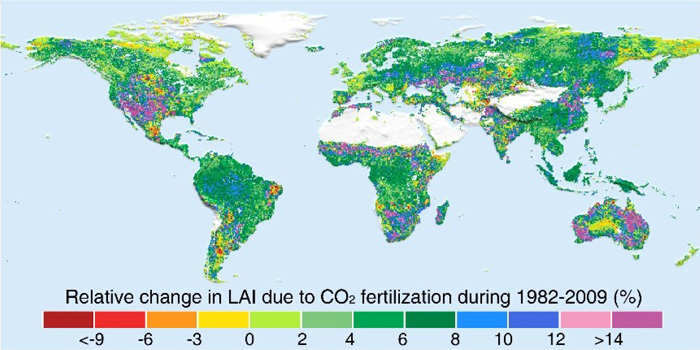

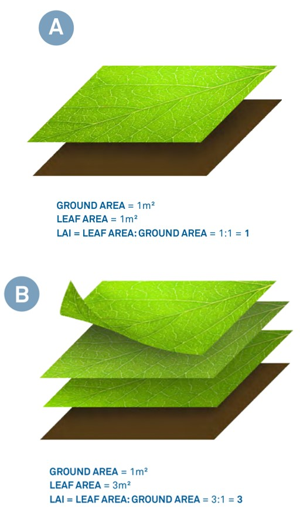

**NDVI - July 22nd 2025**

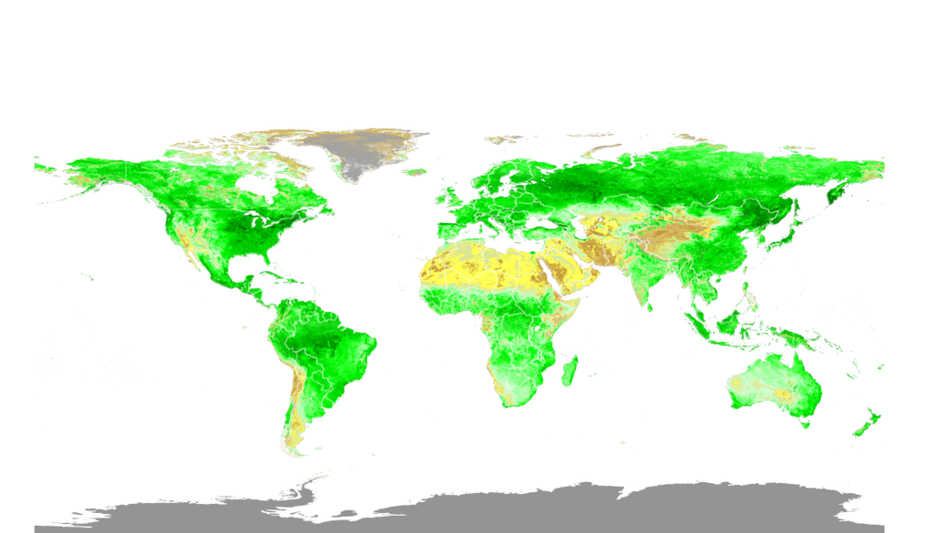

## Why are plants producing more leaf area?

[figure not shown]

- **Humans dump ~40 billion tons of CO<sub>2</sub> into atmosphere**
  - EACH YEAR
- **Atmospheric CO<sub>2</sub> is a greenhouse gas**
  - ↑ CO<sub>2</sub> = ↑ trapped heat = ↑ surface temperatures
- **Plants fix CO<sub>2</sub> from the atmosphere via Rubisco**

## Greenhouse gases make the earth warm

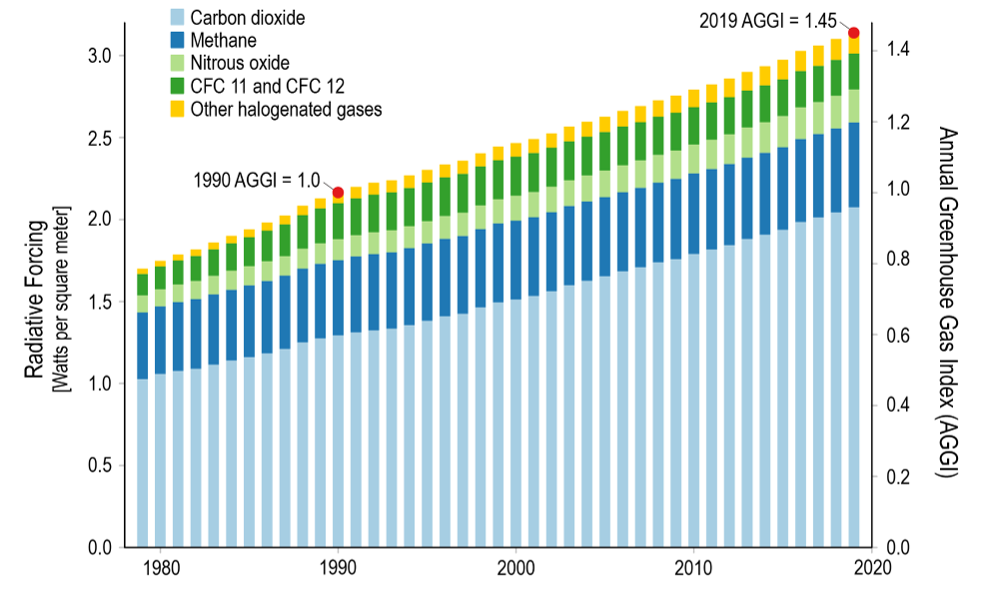

## A carbon *imbalance* exists between surfaces and air

**Human activities have created more carbon sources than natural carbon sinks can absorb**

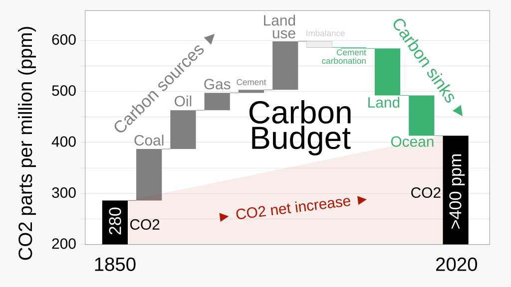

## Plants DO represent a large carbon sink

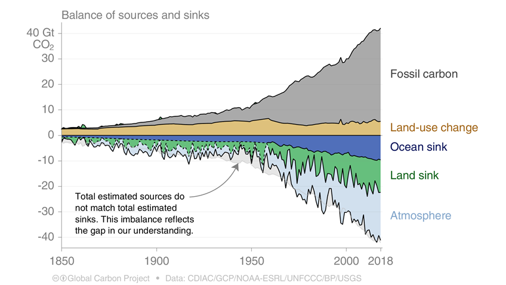

## The role of vegetation change

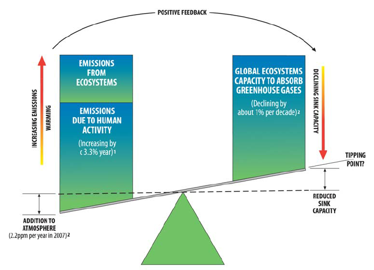

- **Ability to immediately fix carbon from atmosphere**
  - photosynthesis vs respiration
  - keeping pace with human emissions?
- **Sequestrating carbon in wood**
  - prevents fast cycling of carbon
- **Transpiration adds H<sub>2</sub>O into atmosphere**
  - power greenhouse gas

## Plant carbon uptake is multi-layered

**Growing seasons have become longer over time, primarily due to climate change causing earlier springs and later autumns (~2 additionally week in the US since early 1900’s)**

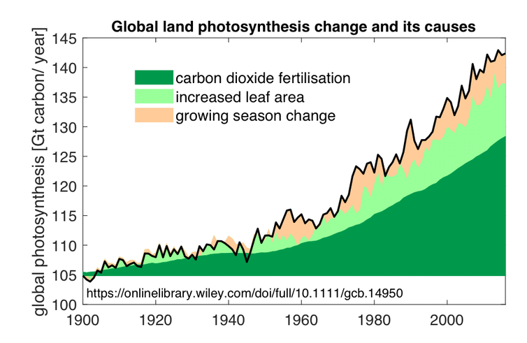

## Vegetation changing with climate is not new!

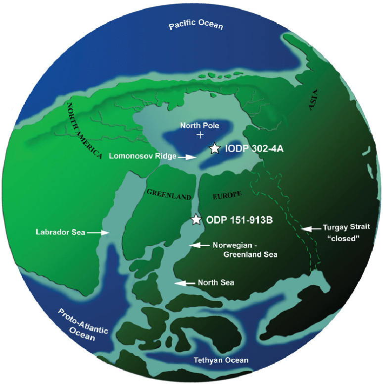

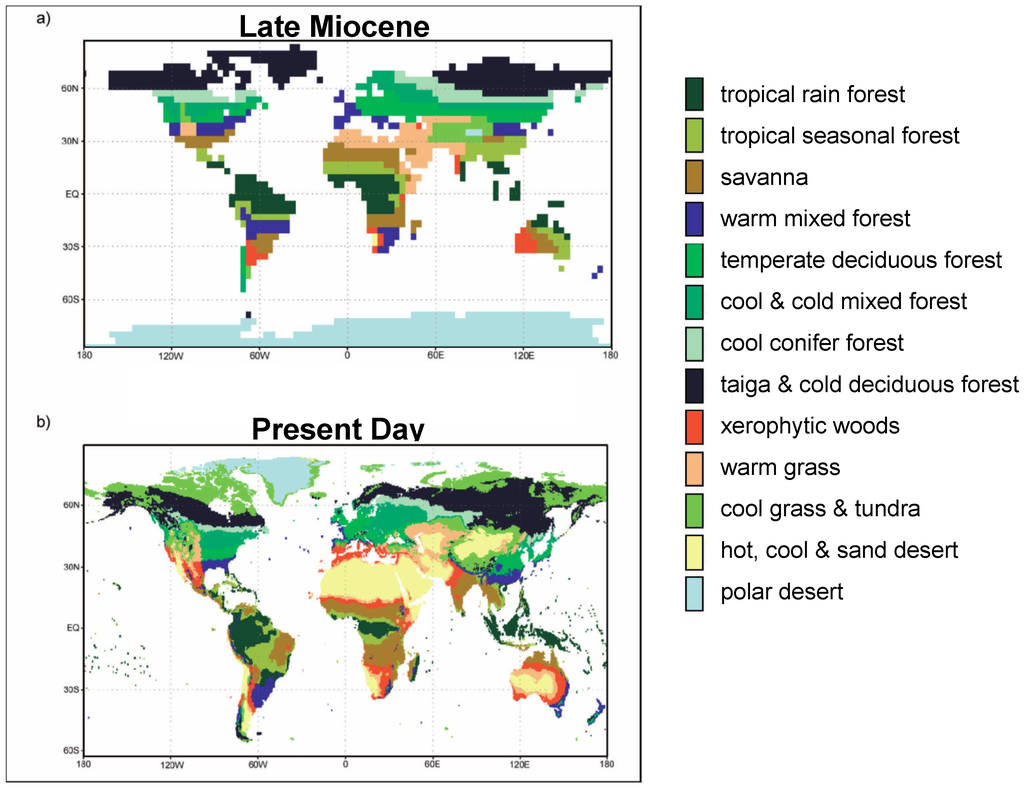

## Global plant C sink: Photosynthesis

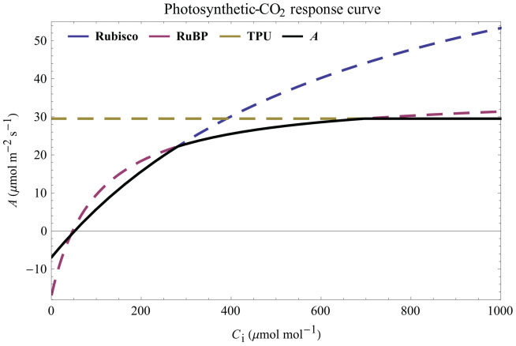

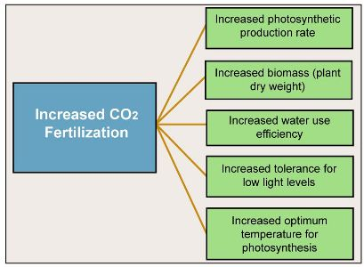

## Just plant tons of trees, problem solved…

[figure not shown]

- **Are all trees carbon vacuums?**
  - fast growing trees don’t live as long
  - fast growing trees drain more water
  - fast growing trees create less dense wood
- **Farmland to forests: can we eat?**
- **Are all forests equal?**
  - forest plantation = rain forest?
- **What happens when forests gets older?**

## How sustainable is the CO<sub>2</sub> fertilization effect

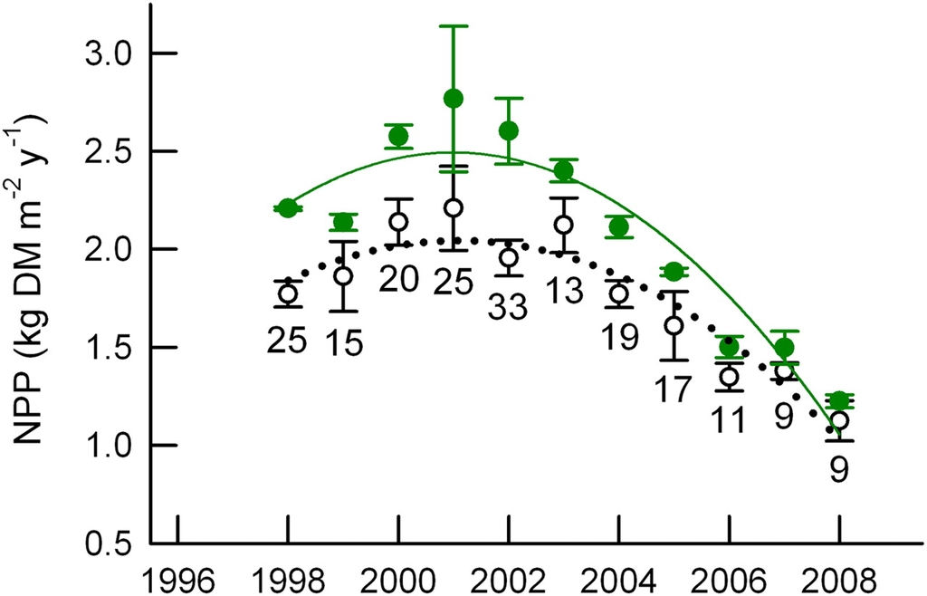

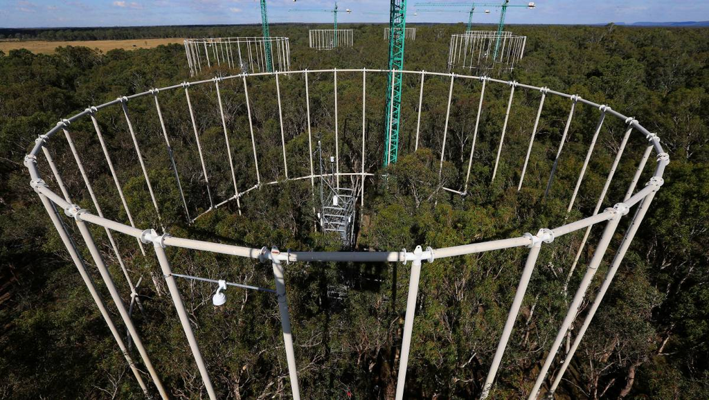

## Global plant C sink: Nutrient limitation

**Question: When will Liebig’s Law of the Minimum take alter global greening?**

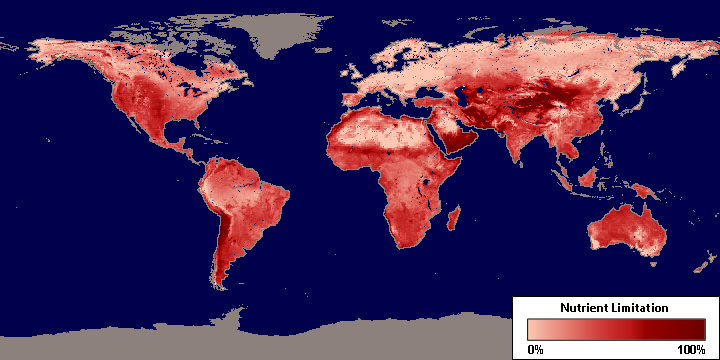

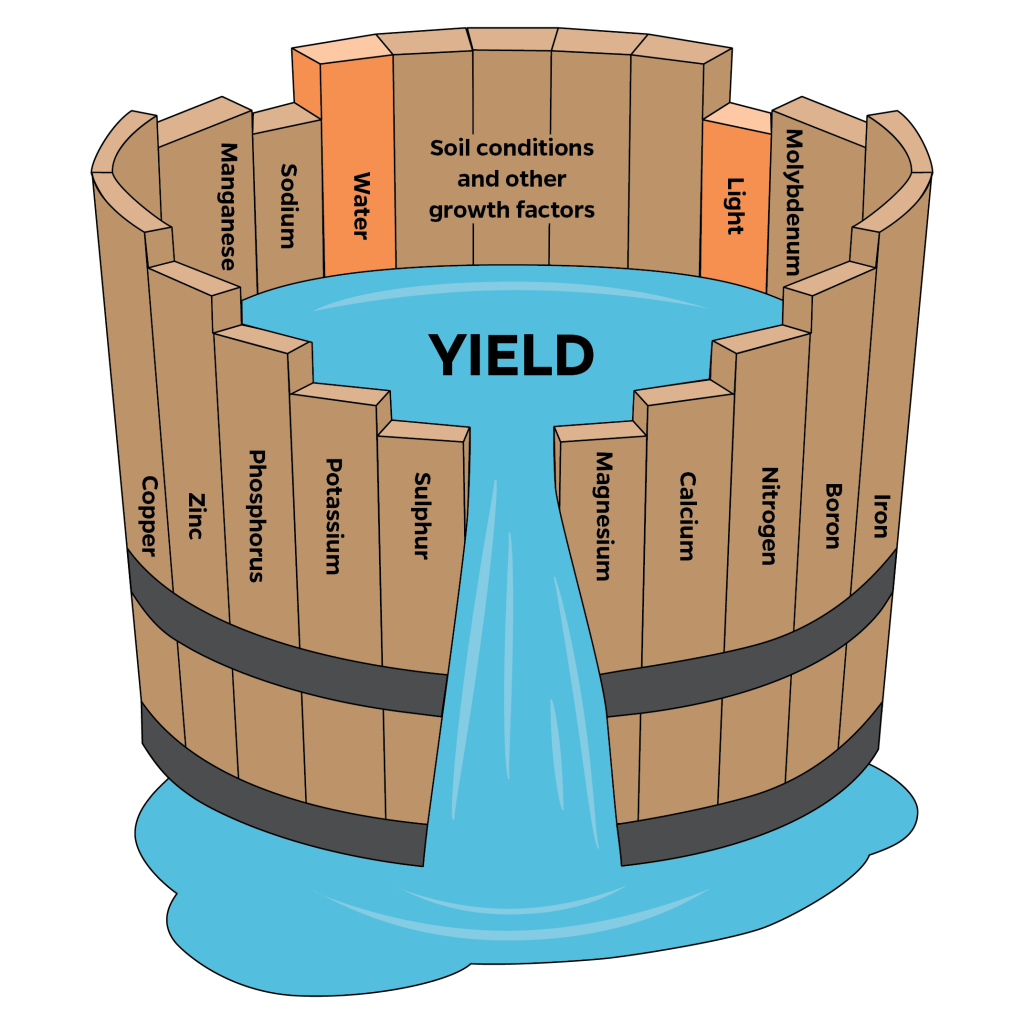

## Global plant C sink: Climate warming

**Question: What is the role of climate warming on the plant carbon sink?**

[figure not shown]

[figure not shown]

## Global plant C sink: Climate warming

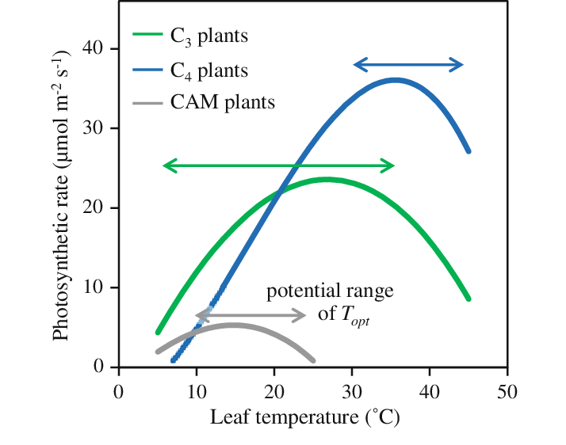

- **Plants like higher temperatures to a degree**
  - faster rate of photosynthesis (limited)
  - most plants not operating at T<sub>opt</sub>
- **Rubisco cheats more at high temperatures**
- **Dependent on stomatal behavior**
- **Warming may also mean ↓ precipitation, ↑ droughts, ↑ wildfires, ↑ heatwaves**

## Global plant C source: Respiration

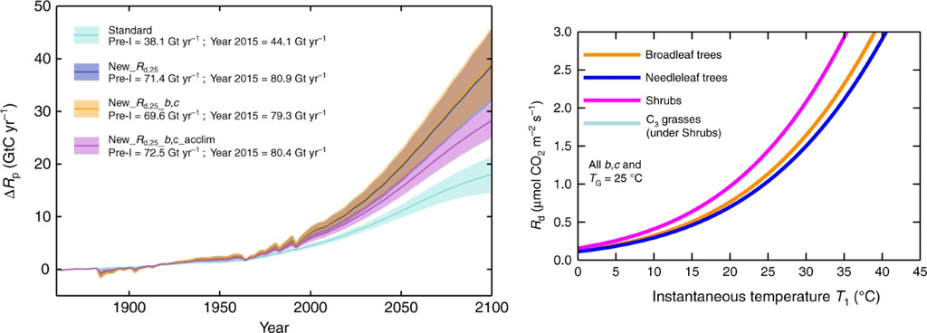

## Climate change is altering precipation regimes

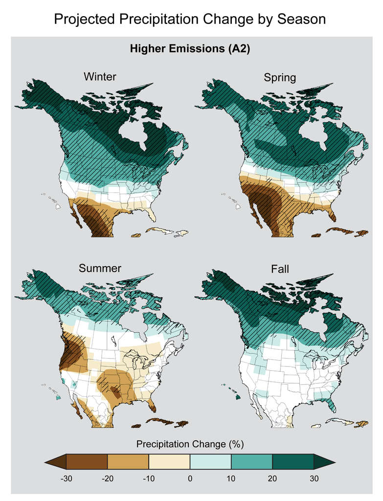

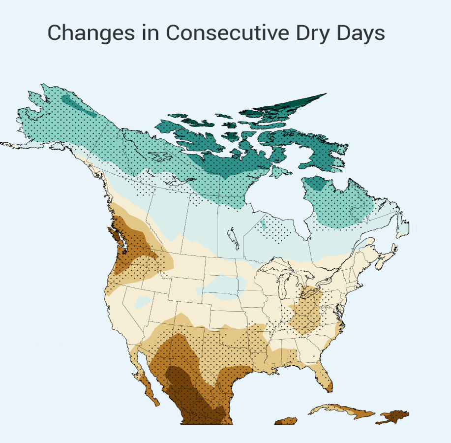

## Key questions: How plastic are plants?

- **Phenotypic plasticity: allows individuals to respond to change within their lifetime**
  - acclimation (lifetime) vs adaptation (generations)
- **Can plants change physiology to match new conditions?**
  - can optimums be adjusted?
- **Why might northern species struggle in warmer temperatures?**
- **Why might plants struggle in new precipitation regimes?**

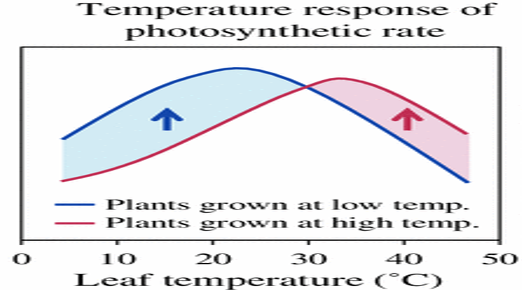

## Climate changes are just part of global change

- **Lots of other stresses on plant communities**
  - impact sustainability of greening earth
- **Habit degradation from human activities**
- **Total habitat loss**
  - agricultural conversion
  - urban growth
- **Higher rates of exotic species invasions**

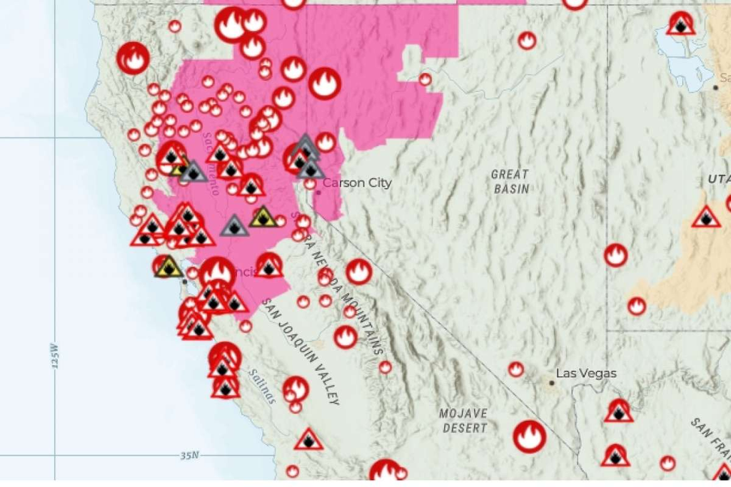

## Is the earth still getting greener?

- **Greening since 1980’s reduced warming ~0.2C**
- **New science suggests browning trend**
  - greening trend stalling or reversing
- **Related to less moisture in the air**
  - higher VPD from climate warming
- **Why would drier air impact plant growth negatively?**
- **Plant carbon sink alone CAN not fix global carbon imbalance**

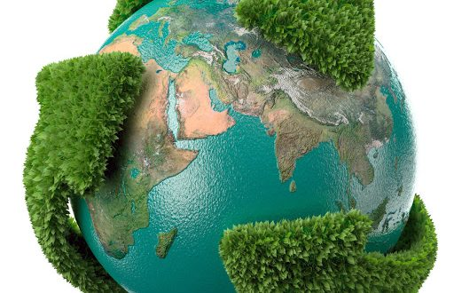